# scratch

Matthew Peverill

2023-03-17

For my current project, I need to generate 5 plots, each of which contain approximately 1.5 billion datapoints. I haven’t tried, but that is likely to seriously cramp my laptops style. The data points are divided amongst 12,000 participants. Since these will get plotted as a hex-mapped density plot anyway, I want to generate hex plot information for each subject individually and then effectively stack them in a memory efficient way. As an added complication, I want to plot a best fit line over the graph.

```
layout: post
title: "Efficiently plotting very large datasets with concatenated hex plots"
author: "Matthew Peverill"
date: "2023-03-17"
output:
  md_document:
    variant: gfm
    preserve_yaml: true
knit: (function(inputFile, encoding) {
    rmarkdown::render(inputFile,
                      encoding = encoding,
                      output_file = file.path(paste0(
                                                  "~/Dropbox/mrpeverill-website/_posts/",
                                                  Sys.Date(),
                                                  '-',
                                                  substr(basename(inputFile), 1, nchar(basename(inputFile)) - 4),
                                                  '.md'
                                                  )
                                              )
                      )
    })
```

# Test Plots

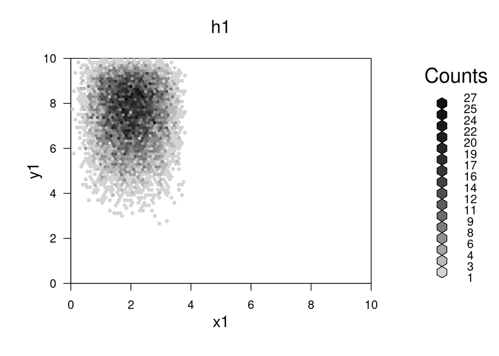

```r
N=10000
x1<-rpert(N,0,2,4,shape=5)
y1<-rpert(N,2,8,10,shape=5)
x2<-rpert(N,6,8,10,shape=5)
y2<-rpert(N,0,2,8,shape=5)
x3<-rpert(N,0,5,10,shape=5)
y3<-rpert(N,0,5,10,shape=5)
xc<-c(x1,x3)
yc<-c(y1,y3)

h1<-hexbin(x1,y1,xbnds=c(0,10),ybnds=c(0,10),xbins=100,shape=.75)
h2<-hexbin(x2,y2,xbnds=c(0,10),ybnds=c(0,10),xbins=100,shape=.75)
h3<-hexbin(x3,y3,xbnds=c(0,10),ybnds=c(0,10),xbins=100,shape=.75)
hc<-hexbin(xc,yc,xbnds=c(0,10),ybnds=c(0,10),xbins=100,shape=.75)

plot(h1,main="h1")
```

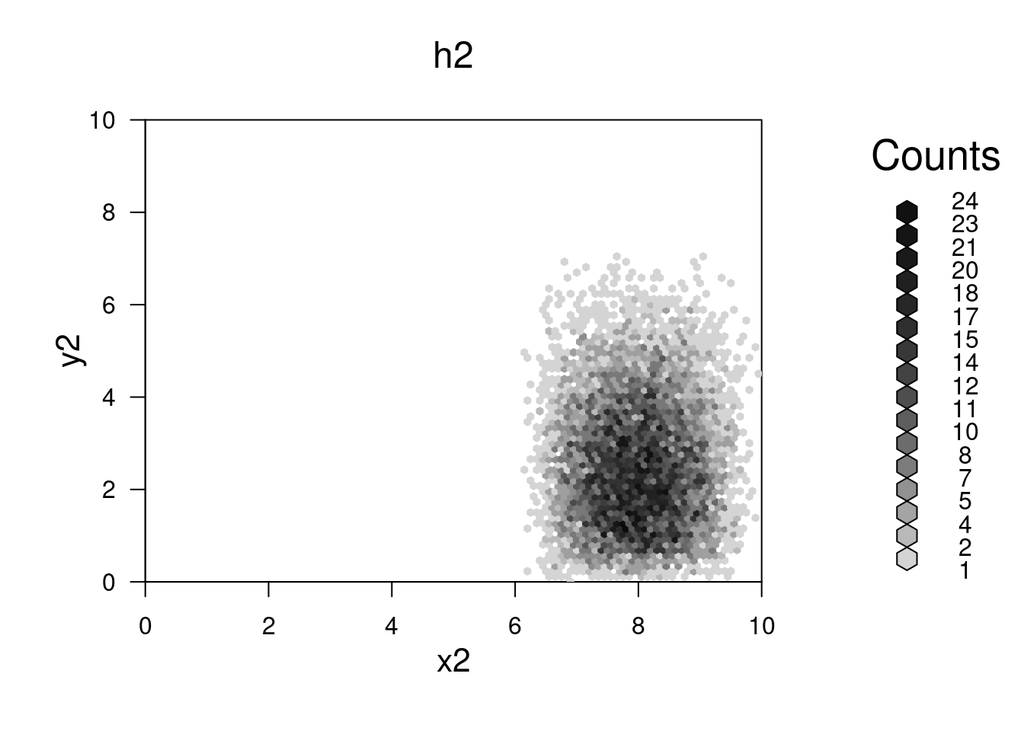

```r
plot(h2,main="h2")
```

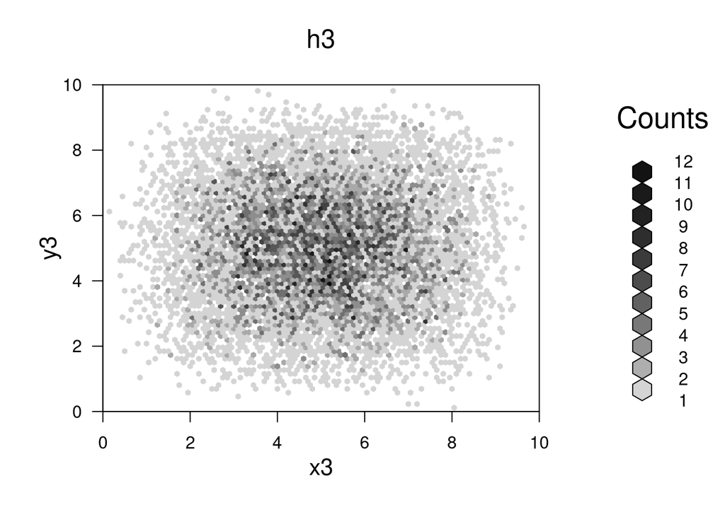

```r
plot(h3,main="h3")
```

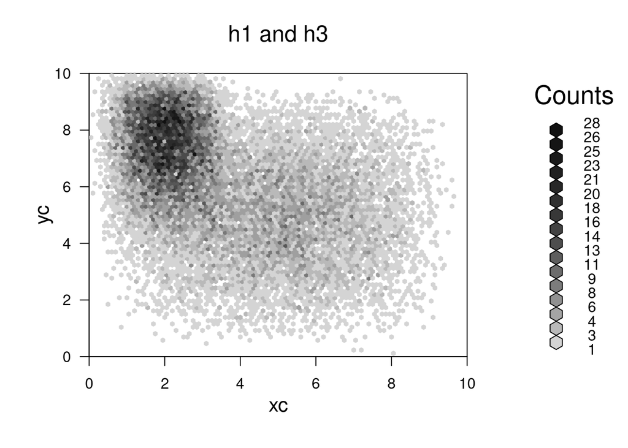

```r
plot(hc,main="h1 and h3")
```

So what we want to do is combine the hexbins without storing the entire vector in memory.

The hexbin object seems to store cell ids and weights separately, which is great for us. On disk, the hex object is 4.3248^{4} bytes, whereas the original vectors were 1.60096^{5} bytes. So the hexbin object does not store the original data.

However:

1. There is no c or ‘+’ method for hexbin.
2. There’s no guarantee there will be the same number of bins.

The hexbin package contains a function, list2hexList, which converts a list of hexbins to a hexList object. They must have the same xbnds, ybnds, and xbins. However, plotting the resulting list doesn’t seem to work (and it does not reduce the data as much as we would like.) So we need to develop a merge function. Importantly, xcm and ycm are the centers of mass of the hexes, not the coordinates.

We need to be able to line up count, xcm, and ycm in a way that maps to the hex coordinates and allows us to stitch them all back together. Given the bounding arguments we’re providing, the hexbin objects have the same grid dimensions, but different numbers of cells:

```r
c(h1,h2,h3)
```

```
## [[1]]
## 'hexbin' object from call: hexbin(x = x1, y = y1, xbins = 100, shape = 0.75, xbnds = c(0,      10), ybnds = c(0, 10))
## n = 10000  points in nc = 1597  hexagon cells in grid dimensions  88 by 101
##
## [[2]]
## 'hexbin' object from call: hexbin(x = x2, y = y2, xbins = 100, shape = 0.75, xbnds = c(0,      10), ybnds = c(0, 10))
## n = 10000  points in nc = 1586  hexagon cells in grid dimensions  88 by 101
##
## [[3]]
## 'hexbin' object from call: hexbin(x = x3, y = y3, xbins = 100, shape = 0.75, xbnds = c(0,      10), ybnds = c(0, 10))
## n = 10000  points in nc = 3968  hexagon cells in grid dimensions  88 by 101
```

There are a couple of functions we can use to extract information about the hexbin object cells. If we specify the IDs=TRUE property, we get the cell IDs of each point in the original dataset, which is not useful to us since data reduction is important. hcell2xy returns the x and y coordinates of each cell id. Specifically, it returns a list of two vectors of length = the number of cells in the hexbin object. By contrast, hcell2xyInt returns a matrix representing the integer coordinates of the grid of all possible cells (which is also not useful).

To strategize, we should figure out if cell id’s map uniquely to an x and y coordinate. So we want to know: do hexbin objects with overlapping/non-overlapping cells share cell ids. Also: do overlapping cell id’s share the same xy coordinates from hcell2xy?

```r
#How much overlap?
celllist<-list(h1@cell,h2@cell,h3@cell)
outer(celllist,celllist,Vectorize(\(x,y) sum(x %in% y)))
```

```
##      [,1] [,2] [,3]
## [1,] 1597    0  728
## [2,]    0 1586  731
## [3,]  728  731 3968
```

Ok, so h1 and h2 have no shared cell id’s – but h3 overlaps with both 1 and 2. This is JUST what we would expect if the cell ids line up with a particular coordinate. Next question – do overlapping cells have the same cell id?

```r
#find 5 cells which overlap between h2 and h3
tcells<-h2@cell[which(h2@cell %in% h3@cell)[1:5]]
h2xy<-hcell2xy(h2)
h3xy<-hcell2xy(h3)

data.frame(h2cellid=h2@cell[h2@cell %in% tcells],
           h3cellid=h3@cell[h3@cell %in% tcells],
           x2=h2xy$x[h2@cell %in% tcells],
           x3=h3xy$x[h3@cell %in% tcells],
           y2=h2xy$y[h2@cell %in% tcells],
           y3=h3xy$y[h3@cell %in% tcells])
```

```
##   h2cellid h3cellid   x2   x3        y2        y3
## 1      182      182 8.05 8.05 0.1154701 0.1154701
## 2      273      273 7.00 7.00 0.2309401 0.2309401
## 3      275      275 7.20 7.20 0.2309401 0.2309401
## 4      573      573 6.75 6.75 0.5773503 0.5773503
## 5      576      576 7.05 7.05 0.5773503 0.5773503
```

Ok, so the cell ids map to specific points on an integer grid defining the possible hexes. Now we can make our function.

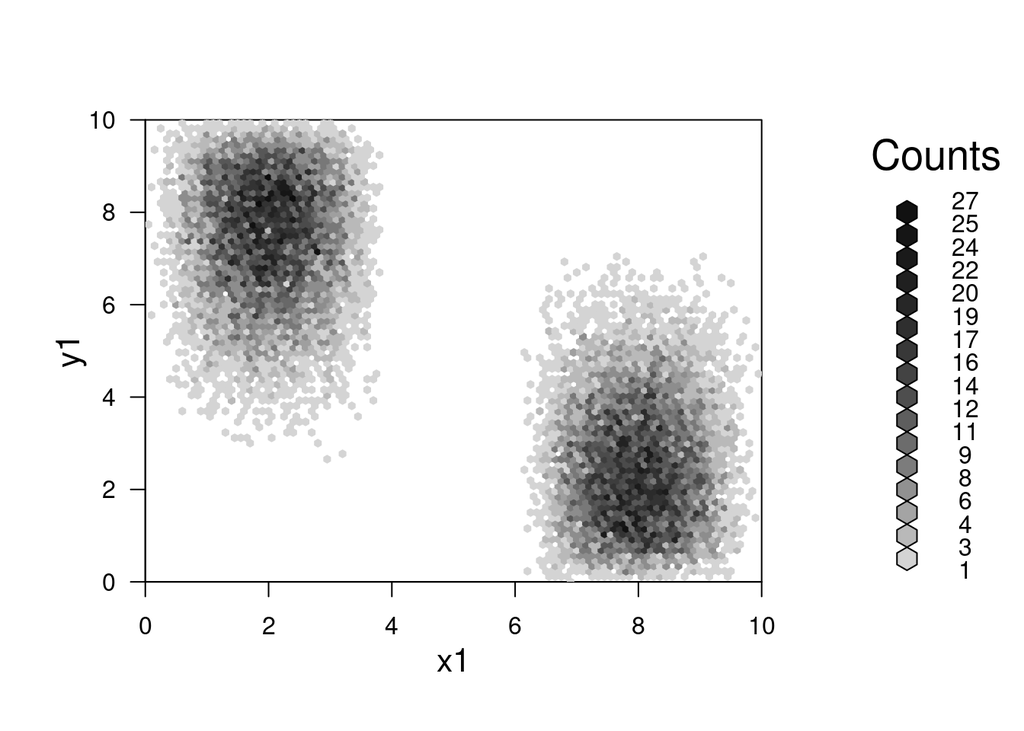

```r
# Get elements from s4 object by name
get_slots <- function(x,nm) Map(\(c) getElement(x, c), nm)

# Unpack hexbin data to be merged in to a dataframe
# Strictly speaking we don't need the xy coordinates, but it is a good error
# check if we have the computation time available.
unpack_hexbin <- function(x) {
  cols <- c("cell", "count", "xcm", "ycm")
  return(cbind(data.frame(get_slots(x,cols)),
                 hcell2xy(x)))
}

# Get columns from a dataframe that should not vary between hexbins to be
# merged.
getmeta_hexbin <- function(x) {
  varying=c("cell", "count", "xcm", "ycm", "call", "n", "ncells")
  other_slots <- setdiff(slotNames(x), varying)
  get_slots(x,other_slots)
}

# Center of mass calculation for two points, robust to missing data.
cm<-function(x1,x2,x1w,x2w) {
  i<-x1*x1w
  j<-x2*x2w
  w<-sum(x1w,x2w,na.rm=TRUE)
  return(sum(i,j,na.rm=TRUE)/w)
}

combine_hexbin <- function(a,b) {
    hm <- merge(unpack_hexbin(a),
                unpack_hexbin(b),
                by = c("cell","x","y"),
                all = TRUE)
    if(any(duplicated(hm$cell))) stop("Duplicate cell Id's detected: Do the hexbin objects have the same grid?")
    hm2 <- hm %>% rowwise() %>% mutate(
      count=sum(count.x,count.y,na.rm=TRUE),
      xcm=cm(xcm.x,xcm.y,count.x,count.y),
      ycm=cm(ycm.x,ycm.y,count.x,count.y)
    )
    do.call(new,
            c(list("hexbin"),
              as.list(hm2[,c("cell",
                             "count",
                             "xcm",
                             "ycm")]),
              list(n = sum(hm2$count),
                   ncells = length(hm2)),
              getmeta_hexbin(a),
              call = quote(call("merged hexbin", 1))
            ))
}

plot(combine_hexbin(h1,h2))
```

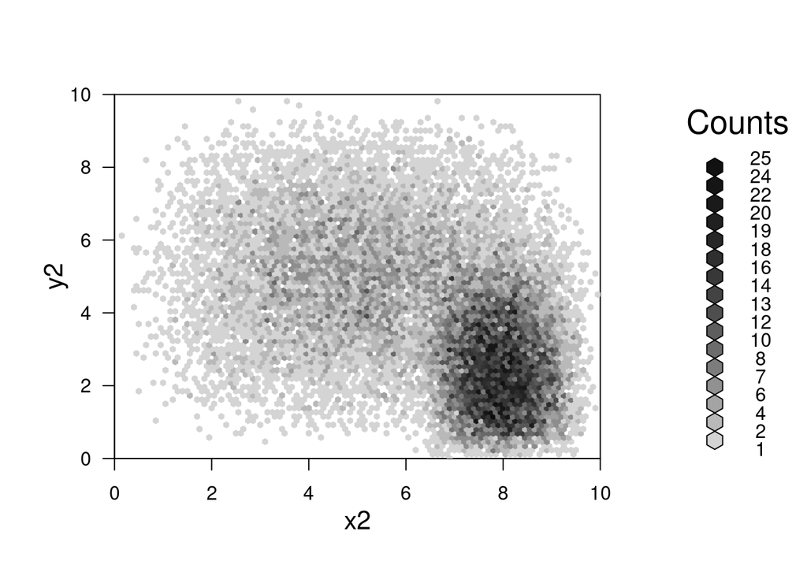

```r
plot(combine_hexbin(h2,h3))
```